# More Graphics

The following presentation is based on the [ggplot2 tutorial](https://github.com/jennybc/ggplot2-tutorial) written by Prof. Jennifer Bryan.

Load the library

```r
library(ggplot2)
```

Read data

```r
gdURL <- "http://tiny.cc/gapminder"
gDat <- read.table(file = gdURL,header=T,sep = "\t")
str(gDat)
```

```
'data.frame':   1698 obs. of  6 variables:
 $ country  : Factor w/ 147 levels "Afghanistan",..: 1 1 1 1 1 1 1 1 1 1 ...
 $ year     : int  1952 1957 1962 1967 1972 1977 1982 1987 1992 1997 ...
 $ pop      : num  8425333 9240934 10267083 11537966 13079460 ...
 $ continent: Factor w/ 5 levels "Africa","Americas",..: 3 3 3 3 3 3 3 3 3 3 ...
 $ lifeExp  : num  28.8 30.3 32 34 36.1 ...
 $ gdpPercap: num  779 821 853 836 740 ...
```

### Bar charts

Consider: number of observations for each continent

```r
table(gDat$continent)
```

```
  Africa Americas     Asia   Europe  Oceania
     618      300      396      360       24
```

This works because default stat for `geom_bar()` is “bin”

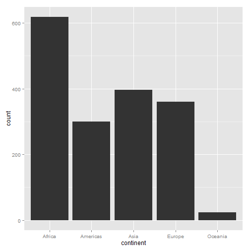

```r
ggplot(gDat, aes(x = continent)) + geom_bar()
```

### Bar charts

Let's reorder the continents based on frequency

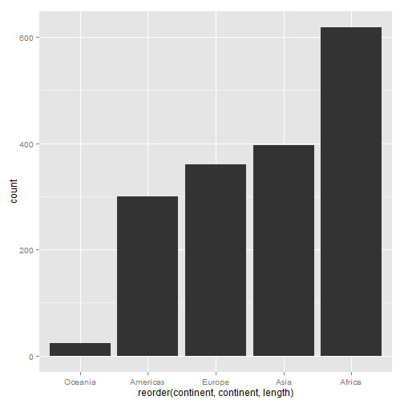

```r
p <- ggplot(gDat, aes(x = reorder(continent, continent, length)))
p + geom_bar()
```

### Bar charts

Would you rather the bars run horizontally?

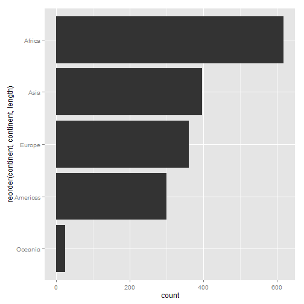

```r
p + geom_bar() + coord_flip()
```

### Bar charts

How about a better data:ink ratio?

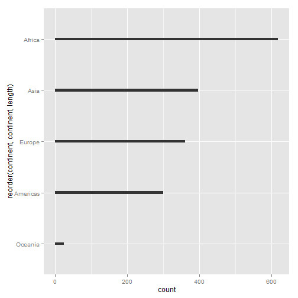

```r
p + geom_bar(width = 0.05) + coord_flip()
```

Consider a scenario where you DON'T want the default “bin” stat, i.e. the bar length or height already exists as a variable

```r
(jDat <- as.data.frame(with(gDat, table(continent, deparse.level = 2))))
```

```
  continent Freq
1    Africa  618
2  Americas  300
3      Asia  396
4    Europe  360
5   Oceania   24
```

This simple call no longer works, because we have pre-tabulated

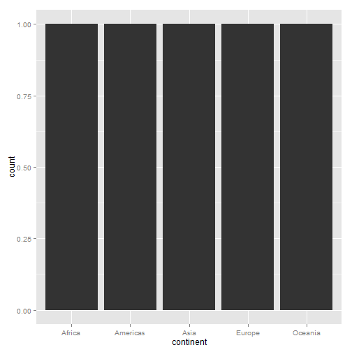

```r
ggplot(jDat, aes(x = continent)) + geom_bar()
```

THIS works when bar length or height already exists

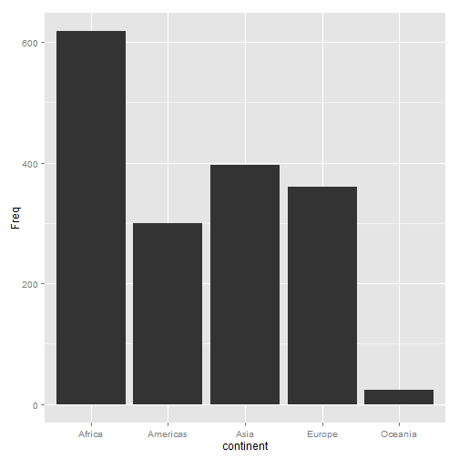

```r
ggplot(jDat, aes(x = continent, y = Freq)) + geom_bar(stat = "identity")
```

### Themes

The appearance of non-data elements of the plit is controlled by the theme system

```r
library(ggthemes)
```

### Themes

Revisit a plot from earlier

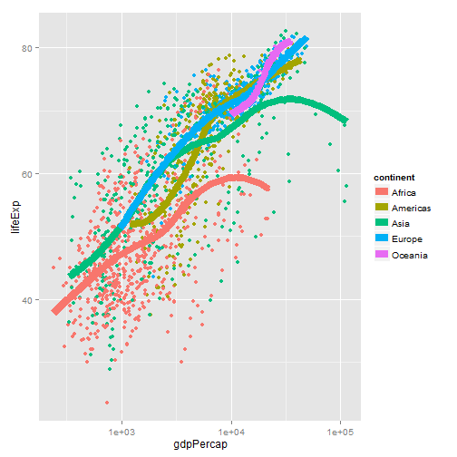

```r
p <- ggplot(gDat, aes(x = gdpPercap, y = lifeExp))
p <- p + scale_x_log10()
p <- p + aes(color = continent) + geom_point() + geom_smooth(lwd = 3, se = FALSE)
p
```

### Titles

Give it a title

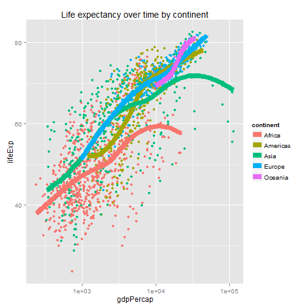

```r
p + ggtitle("Life expectancy over time by continent")
```

### Themes

Change overall look and feel with a premade theme

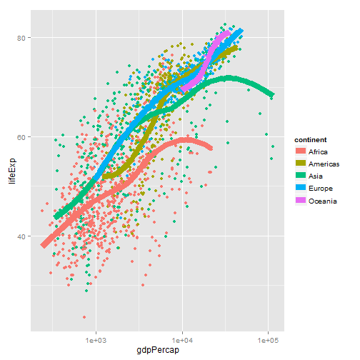

```r
p + theme_grey() # the default
```

### Themes

Suppress the usual grey background

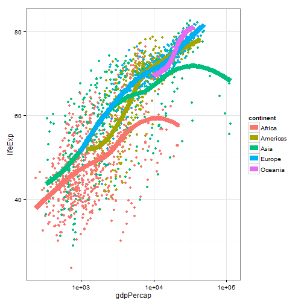

```r
p + theme_bw()
```

### Themes

Exploring some themes from the ggthemes package

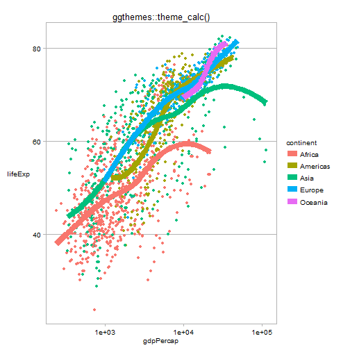

```r
p + theme_calc() + ggtitle("ggthemes::theme_calc()")
```

### Themes

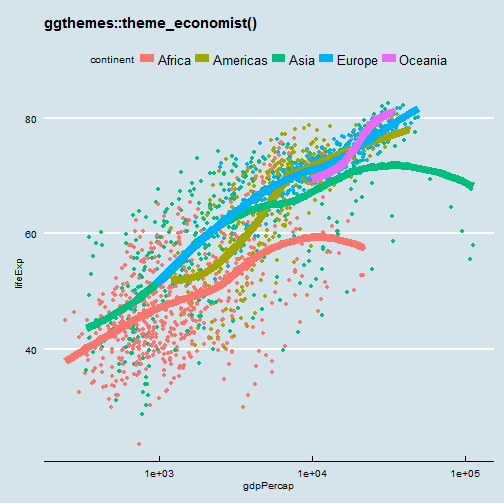

```r
p + theme_economist() + ggtitle("ggthemes::theme_economist()")
```

### Themes

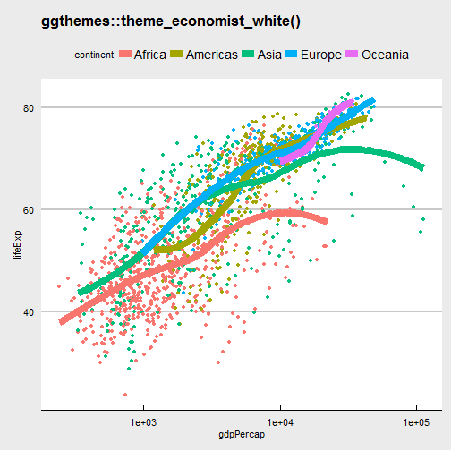

```r
p + theme_economist_white() + ggtitle("ggthemes::theme_economist_white()")
```

### Themes

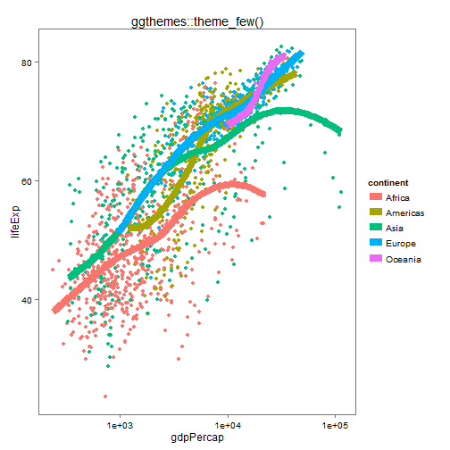

```r
p + theme_few() + ggtitle("ggthemes::theme_few()")
```

### Themes

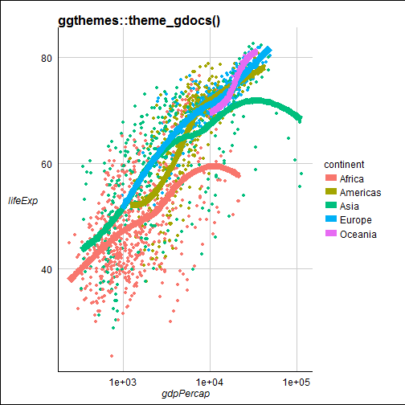

```r
p + theme_gdocs() + ggtitle("ggthemes::theme_gdocs()")
```

### Themes

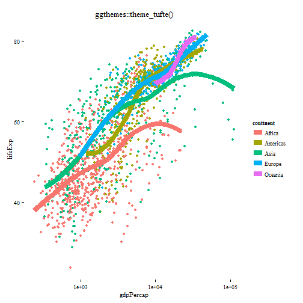

```r
p + theme_tufte() + ggtitle("ggthemes::theme_tufte()")
```

### Themes

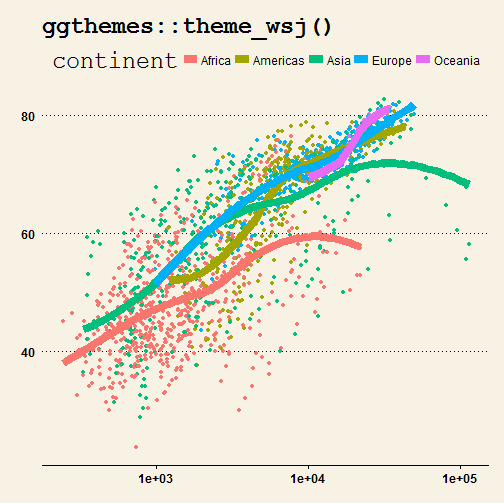

```r
p + theme_wsj() + ggtitle("ggthemes::theme_wsj()")
```

### Colors

Let just look at four countries

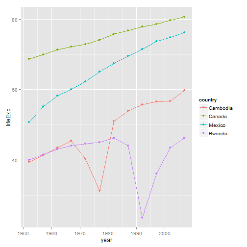

```r
jCountries <- c("Canada", "Rwanda", "Cambodia", "Mexico")
x <- droplevels(subset(gDat, country %in% jCountries))
ggplot(x, aes(x = year, y = lifeExp, color = country)) +
  geom_line() + geom_point()
```

### Colors

Reorder the country factor to reflect `lifeExp` in 2007

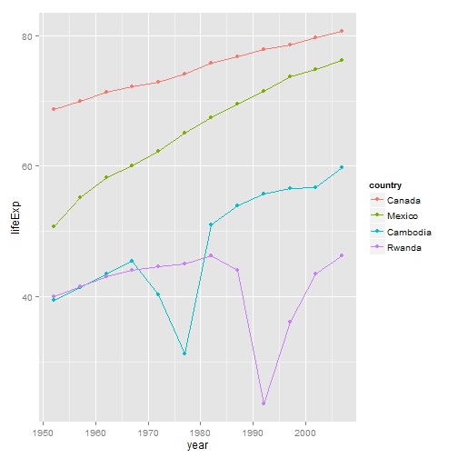

```r
x <- transform(x, country = reorder(country, -1 * lifeExp, max))
ggplot(x, aes(x = year, y = lifeExp, color = country)) +
  geom_line() + geom_point()
```

### Colors

Look at the RColorBrewer color palettes

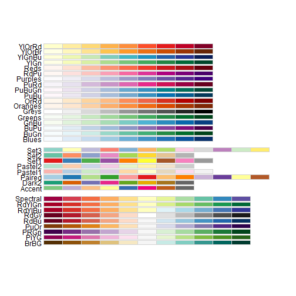

```r
library("RColorBrewer")
display.brewer.all()
```

### Colors

Focus on the qualitative palettes

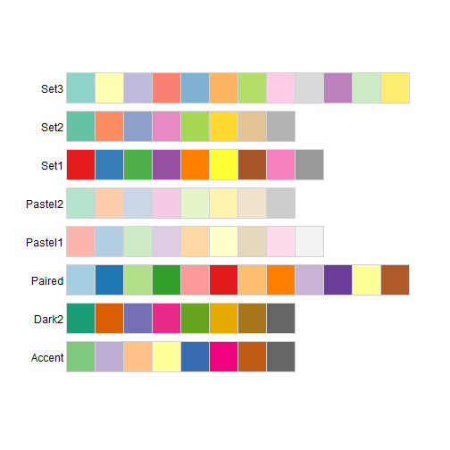

```r
display.brewer.all(type = "qual")
```

### Colors

Pick some colors

```r
#' pick some colors
jColors = brewer.pal(n = 8, "Dark2")[seq_len(nlevels(x$country))]
names(jColors) <- levels(x$country)
```

### Colors

Remake the plot with our new colors

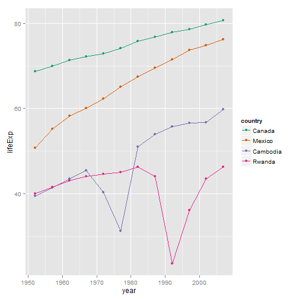

```r
ggplot(x, aes(x = year, y = lifeExp, color = country)) +
  geom_line() + geom_point() +
  scale_color_manual(values = jColors)
```

### Colors

Pick some super ugly colors for shock value

```r
kColors = c("darkorange2", "deeppink3", "lawngreen", "peachpuff4")
names(kColors) <- levels(x$country)
```

Remake the plot with our ugly colors

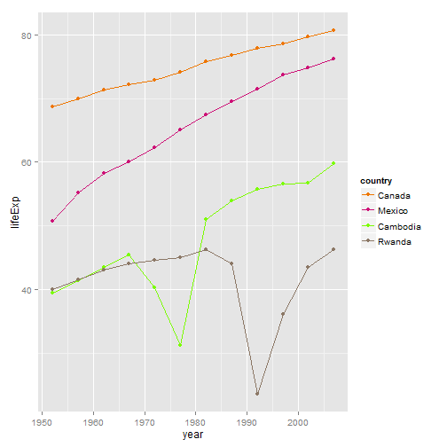

```r
ggplot(x, aes(x = year, y = lifeExp, color = country)) +
  geom_line() + geom_point() +
  scale_color_manual(values = kColors)
```

Load the color scheme

```r
country_colors <- read.delim("gapminder-country-colors.tsv",
                             colClasses = list(color = "character"))
str(country_colors)
```

```
'data.frame':   142 obs. of  3 variables:
 $ continent: Factor w/ 5 levels "Africa","Americas",..: 1 1 1 1 1 1 1 1 1 1 ...
 $ country  : Factor w/ 142 levels "Afghanistan",..: 95 39 43 118 28 86 3 121 127 69 ...
 $ color    : chr  "#7F3B08" "#833D07" "#873F07" "#8B4107" ...
```

Drop Oceania

```r
gDat <- droplevels(subset(gDat, continent != "Oceania"))
country_colors <- droplevels(subset(country_colors, continent != "Oceania"))

jYear <- 2007 # this can obviously be changed
jPch <- 21
jDarkGray <- 'grey20'
jXlim <- c(150, 115000)
jYlim <- c(16, 100)
```

Handy for ggplot2 `scale_fill_manual()`

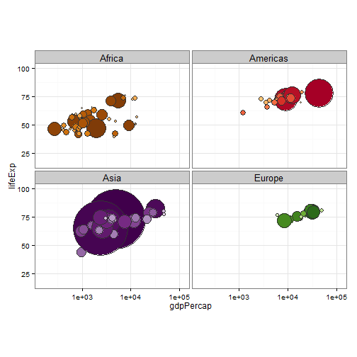

```r
jColors <- country_colors$color
names(jColors) <- country_colors$country

ggplot(subset(gDat, year == jYear),
       aes(x = gdpPercap, y = lifeExp)) +
  scale_x_log10(limits = jXlim) + ylim(jYlim) +
  geom_point(aes(size = sqrt(pop/pi)), pch = jPch, color = jDarkGray,
             show_guide = FALSE) +
  scale_size_continuous(range=c(1,40)) +
  facet_wrap(~ continent) + coord_fixed(ratio = 1/43) +
  aes(fill = country) + scale_fill_manual(values = jColors) +
  theme_bw() + theme(strip.text = element_text(size = rel(1.1)))
```